# TAR 295: Family Tax Credit rate and (single-tier) abatement options with comparison to pre- and post-indexation status quo settings

[BUDGET-SENSITIVE]

Note: This report is best viewed with **Google Chrome**. Please press and hold the **“Ctrl” key**, and then press the **“-” or “+” keys** on the keyboard, to **zoom-out or zoom-in**.

## Summary

TAR 291 thoroughly canvassed a broad range of one- and two-tier Working for Families abatement setting and per child rate increases for the Family Tax Credit. This enabled the selection of several potential settings on the “child poverty reduction frontier” that achieved the highest poverty reductions for given fiscal costs, while also avoiding bringing new families into AHC50 poverty, or making families already in AHC50 poverty worse off, which were issues for the more redistributive options in TAR 286. Ministers have ruled out the two-tiered abatement options, and have indicated an interest in the lower fiscal cost single-tier options.

Although TAR 291 did explore all combinations in a grid of FTC rate increases and abatement rates, detailed analysis, including distributional analysis, was only done for a few 1-tier options. This TAR provides this detailed analysis for a few more low-cost 1-tier settings.

EMTR plots, similar to those produced in TAR 291 – part 6, will also be supplied in a separate TAR (296).

### Some observations

- The fiscal and poverty outputs have already been covered in previous analysis; the only new aspect here is the addition of the 95% margin of error for the three scenarios not previously modelled in detail. **These uncertainties are significant, particularly for the poverty metrics.**
- The household and family winners and losers plots show that
  - most losing households are in the fourth household equivalised disposable income (HEDI) decile
  - for all settings the average gains for gaining households increase steadily with decreasing HEDI
  - for all settings HEDI deciles 1, 3, and 4 have the most gaining households.
  - when assessed against the pre-indexation status quo, losses are less noticeable, and for some settings they disappear. Also, gains are noticeable right up to the top decile – probably due to Best Start indexation.
  - there is a striking similarity between the post-indexation winner and loser distributions of the $5/27% option and the $7.50/28%, though obviously the magnitude of gains and losses is greater in the latter.
  - for the $5/27% and $7.50/28% options, in total, less WFF spending (after indexation) is going to the population with family taxable income over $100k. However, with the FTC/BSTC indexation included the total change in spend is still positive for this population.

## Request Outline

### Requestor

Maudie Johnson-hunter (MSD)

### Time frame

10th October

Sent on: 01 October 2021.

### Outputs

For tax year 2022-23, using HES20/IDI input, the BEFU21 forecast and the settings in the table below:

1. Standard TAWA outputs, including fiscal costs, poverty metrics, and winners and losers by household equivalised disposable income (HEDI) deciles with respect to a post- FTC/BSTC indexation status quo.
2. Winners and losers by household equivalised disposable income (HEDI) deciles with respect to a pre- FTC/BSTC indexation status quo.
3. Winning and losing families by family taxable income bins ($10k steps up to $140k, and under/over $100k, as per TAR 292) with respect to a post- FTC/BSTC indexation status quo.
4. Winning and losing families by family taxable income bins ($10k steps up to $140k, and under/over $100k, as per TAR 292) with respect to a pre- FTC/BSTC indexation status quo.

### Scenarios

The options considered here are all have a single-tier of abatement, with the abatement threshold set at its current value of $42,700. Only the per-child rate of FTC payment, and the abatement rate are varied. The options are:

| Weekly per-child FTC increase ($) | Abatement Rate (%) |
| --- | --- |
| 5.0 | 25 (current) |
| 5.0 | 26 |
| 5.0 | 27 |
| 7.5 | 27 |
| 7.5 | 28 |

## Results

### Main impacts

Comparison of main impacts

| Option | Post FTC/BSTC indexation Annual Fiscal cost* | Post FTC/BSTC indexation Reduction in number of Children Fixed AHC50† | Post FTC/BSTC indexation Reduction in number of Children BHC50† | Post FTC/BSTC indexation Number of gaining households‡ | Post FTC/BSTC indexation Average gain per week for gaining households<sup>§</sup> | Post FTC/BSTC indexation Number of losing households‡ | Post FTC/BSTC indexation Average loss per week for losing households<sup>§</sup> | Pre FTC/BSTC indexation Number of gaining households<sup>¶</sup> | Pre FTC/BSTC indexation Average gain per week for gaining households** | Pre FTC/BSTC indexation Number of losing households<sup>¶</sup> | Pre FTC/BSTC indexation Average loss per week for losing households** |
| --- | --- | --- | --- | --- | --- | --- | --- | --- | --- | --- | --- |
| $5,25% | $158m | 9,000 | 5,000 | 316,000 | $10 | Suppressed | Suppressed | 345,000 | $20 | Suppressed | Suppressed |
| $5,26% | $111m | 9,000 | 5,000 | 287,000 | $8 | 26,000 | -$1 | 340,000 | $18 | Suppressed | Suppressed |
| $5,27% | $68m | 8,000 | 5,000 | 223,000 | $8 | 89,000 | -$6 | 330,000 | $16 | 8,000 | -$1 |
| $7.50,27% | $145m | 11,000 | 7,000 | 254,000 | $12 | 59,000 | -$3 | 337,000 | $20 | Suppressed | Suppressed |
| $7.50,28% | $103m | 10,000 | 7,000 | 223,000 | $12 | 89,000 | -$8 | 309,000 | $20 | 27,000 | -$3 |

* MoE for annual fiscal costs are up to $10m  
† MoE for poverty measures are up to 6,000  
‡ MoE for numbers of winners and losers analysis measures are up to 11,000  
<sup>§</sup> MoE for weekly gains/losses of winners and losers analysis measures are up to $1  
<sup>¶</sup> MoE for numbers of winners and losers analysis (Pre FTC/BSTC indexation) measures are up to 12,000  
** MoE for weekly gains/losses of winners and losers analysis (Pre FTC/BSTC indexation) measures are up to $1

### Annual fiscal impacts (Post FTC/BSTC indexation as Status Quo)

Breakdown of annual fiscal impacts

| Scenario | Total ($ m) | Total ($ m) | Total ($ m) | Accommodation Supplement ($ m) | Accommodation Supplement ($ m) | Accommodation Supplement ($ m) | Family Tax Credit ($ m) | Family Tax Credit ($ m) | Family Tax Credit ($ m) | In Work Tax Credit ($ m) | In Work Tax Credit ($ m) | In Work Tax Credit ($ m) | Independent Earner Tax Credit ($ m) | Independent Earner Tax Credit ($ m) | Independent Earner Tax Credit ($ m) |
| --- | --- | --- | --- | --- | --- | --- | --- | --- | --- | --- | --- | --- | --- | --- | --- |
| $5,25% | $158 | ± | $5 | -$3 | ± | $0 | $143 | ± | $5 | $20 | ± | $2 | -$1 | ± | $1 |
| $5,26% | $111 | ± | $5 | -$3 | ± | $0 | $115 | ± | $5 | -$1 | ± | $0 | $0 | ± | $0 |
| $5,27% | $68 | ± | $6 | -$3 | ± | $0 | $90 | ± | $6 | -$20 | ± | $2 | $1 | ± | $0 |
| $7.50,27% | $145 | ± | $8 | -$5 | ± | $0 | $160 | ± | $8 | -$10 | ± | $1 | $1 | ± | $0 |
| $7.50,28% | $103 | ± | $10 | -$5 | ± | $0 | $136 | ± | $9 | -$29 | ± | $3 | $1 | ± | $1 |

### Total Populations

#### Table of different population types

Summary of total numbers of households, families, adults, and children

| Total populations (thousand) Households | Total populations (thousand) Households | Total populations (thousand) Households | Total populations (thousand) Families | Total populations (thousand) Families | Total populations (thousand) Families | Total populations (thousand) Adults | Total populations (thousand) Adults | Total populations (thousand) Adults | Total populations (thousand) Children | Total populations (thousand) Children | Total populations (thousand) Children |
| --- | --- | --- | --- | --- | --- | --- | --- | --- | --- | --- | --- |
| 1,848 | ± | 1 | 2,691 | ± | 15 | 3,906 | ± | 7 | 1,155 | ± | 7 |

### Poverty Measures (Post FTC/BSTC indexation as Status Quo)

#### Fixed line after-housing-cost

##### Change in numbers in poverty

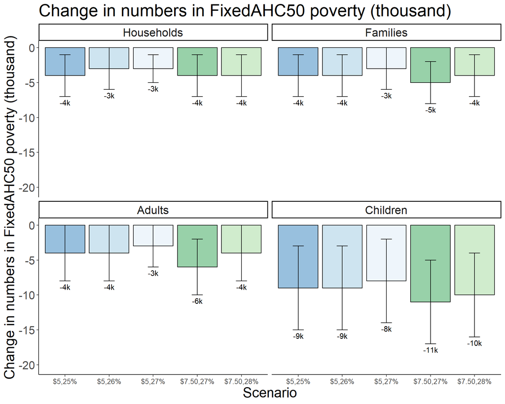

##### Data

###### Table of poverty measures: Fixed line after-housing-cost

| Fixed line after-housing-cost poverty indicators Scenario | Populations (thousand) with incomes below FixedAHC Households | Populations (thousand) with incomes below FixedAHC Households | Populations (thousand) with incomes below FixedAHC Households | Populations (thousand) with incomes below FixedAHC Families | Populations (thousand) with incomes below FixedAHC Families | Populations (thousand) with incomes below FixedAHC Families | Populations (thousand) with incomes below FixedAHC Adults | Populations (thousand) with incomes below FixedAHC Adults | Populations (thousand) with incomes below FixedAHC Adults | Populations (thousand) with incomes below FixedAHC Children | Populations (thousand) with incomes below FixedAHC Children | Populations (thousand) with incomes below FixedAHC Children | Average depth of households with incomes below FixedAHC | Average depth of households with incomes below FixedAHC | Average depth of households with incomes below FixedAHC | Median equivalised FixedAHC income | Median equivalised FixedAHC income | Median equivalised FixedAHC income |
| --- | --- | --- | --- | --- | --- | --- | --- | --- | --- | --- | --- | --- | --- | --- | --- | --- | --- | --- |
| Status Quo | 246 | ± | 15 | 323 | ± | 20 | 415 | ± | 25 | 160 | ± | 17 | $10,800 | ± | $600 | $35,600 | ± | $700 |
| **Package** |  |  |  |  |  |  |  |  |  |  |  |  |  |  |  |  |  |  |
| $5,25% | 243 | ± | 14 | 320 | ± | 19 | 410 | ± | 24 | 151 | ± | 16 | $10,800 | ± | $600 | $35,600 | ± | $700 |
| $5,26% | 243 | ± | 14 | 320 | ± | 19 | 411 | ± | 24 | 151 | ± | 16 | $10,900 | ± | $600 | $35,600 | ± | $700 |
| $5,27% | 243 | ± | 14 | 320 | ± | 19 | 412 | ± | 24 | 152 | ± | 17 | $10,900 | ± | $600 | $35,600 | ± | $700 |
| $7.50,27% | 242 | ± | 14 | 319 | ± | 19 | 409 | ± | 23 | 149 | ± | 16 | $10,800 | ± | $600 | $35,600 | ± | $700 |
| $7.50,28% | 243 | ± | 14 | 319 | ± | 19 | 411 | ± | 24 | 150 | ± | 16 | $10,800 | ± | $600 | $35,600 | ± | $700 |
| **Difference from Status Quo** |  |  |  |  |  |  |  |  |  |  |  |  |  |  |  |  |  |  |
| $5,25% | -4 | ± | 3 | -4 | ± | 3 | -4 | ± | 4 | -9 | ± | 6 | $0 | ± | $100 | 0 | ± | 0 |
| $5,26% | -3 | ± | 3 | -4 | ± | 3 | -4 | ± | 4 | -9 | ± | 6 | $0 | ± | $100 | 0 | ± | 0 |
| $5,27% | -3 | ± | 2 | -3 | ± | 3 | -3 | ± | 3 | -8 | ± | 6 | $0 | ± | $100 | 0 | ± | 0 |
| $7.50,27% | -4 | ± | 3 | -5 | ± | 3 | -6 | ± | 4 | -11 | ± | 6 | $0 | ± | $200 | 0 | ± | 0 |
| $7.50,28% | -4 | ± | 3 | -4 | ± | 3 | -4 | ± | 4 | -10 | ± | 6 | $0 | ± | $100 | 0 | ± | 0 |

#### Moving line before-housing-cost

##### Change in numbers in poverty

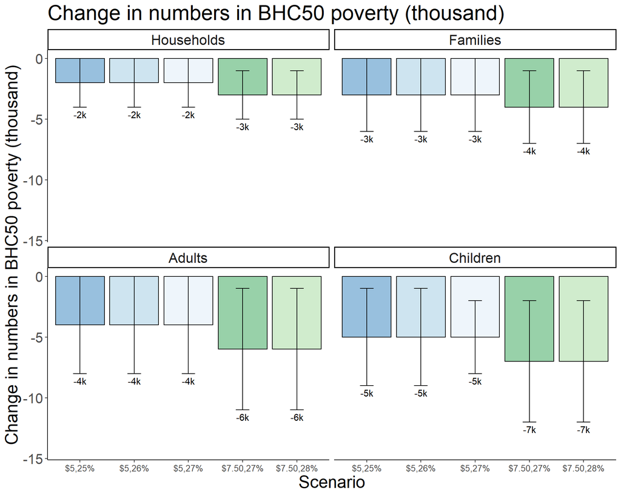

##### Data

###### Table of poverty measures: Moving line before-housing-cost

| Moving line before-housing-cost poverty indicators Scenario | Populations (thousand) with incomes below BHC Households | Populations (thousand) with incomes below BHC Households | Populations (thousand) with incomes below BHC Households | Populations (thousand) with incomes below BHC Families | Populations (thousand) with incomes below BHC Families | Populations (thousand) with incomes below BHC Families | Populations (thousand) with incomes below BHC Adults | Populations (thousand) with incomes below BHC Adults | Populations (thousand) with incomes below BHC Adults | Populations (thousand) with incomes below BHC Children | Populations (thousand) with incomes below BHC Children | Populations (thousand) with incomes below BHC Children | Average depth of households with incomes below BHC | Average depth of households with incomes below BHC | Average depth of households with incomes below BHC | Median equivalised BHC income | Median equivalised BHC income | Median equivalised BHC income |
| --- | --- | --- | --- | --- | --- | --- | --- | --- | --- | --- | --- | --- | --- | --- | --- | --- | --- | --- |
| Status Quo | 131 | ± | 9 | 183 | ± | 14 | 232 | ± | 17 | 92 | ± | 13 | $10,700 | ± | $800 | $46,700 | ± | $700 |
| **Package** |  |  |  |  |  |  |  |  |  |  |  |  |  |  |  |  |  |  |
| $5,25% | 129 | ± | 9 | 181 | ± | 14 | 228 | ± | 17 | 87 | ± | 12 | $10,700 | ± | $800 | $46,700 | ± | $700 |
| $5,26% | 129 | ± | 9 | 181 | ± | 14 | 228 | ± | 17 | 87 | ± | 12 | $10,600 | ± | $800 | $46,700 | ± | $700 |
| $5,27% | 129 | ± | 9 | 181 | ± | 14 | 228 | ± | 17 | 87 | ± | 13 | $10,700 | ± | $800 | $46,700 | ± | $700 |
| $7.50,27% | 128 | ± | 9 | 179 | ± | 14 | 226 | ± | 17 | 84 | ± | 13 | $10,700 | ± | $800 | $46,700 | ± | $700 |
| $7.50,28% | 128 | ± | 9 | 179 | ± | 14 | 226 | ± | 17 | 84 | ± | 13 | $10,700 | ± | $800 | $46,700 | ± | $700 |
| **Difference from Status Quo** |  |  |  |  |  |  |  |  |  |  |  |  |  |  |  |  |  |  |
| $5,25% | -2 | ± | 2 | -3 | ± | 3 | -4 | ± | 4 | -5 | ± | 4 | $0 | ± | $200 | $0 | ± | $100 |
| $5,26% | -2 | ± | 2 | -3 | ± | 3 | -4 | ± | 4 | -5 | ± | 4 | $0 | ± | $200 | $0 | ± | $100 |
| $5,27% | -2 | ± | 2 | -3 | ± | 3 | -4 | ± | 4 | -5 | ± | 3 | $0 | ± | $200 | $0 | ± | $100 |
| $7.50,27% | -3 | ± | 2 | -4 | ± | 3 | -6 | ± | 5 | -7 | ± | 5 | $0 | ± | $200 | $0 | ± | $100 |
| $7.50,28% | -3 | ± | 2 | -4 | ± | 3 | -6 | ± | 5 | -7 | ± | 5 | $0 | ± | $200 | $0 | ± | $100 |

### Household winners and losers

#### Post FTC/BSTC indexation as Status Quo

##### Figures

###### Winners and Losers by HEDI decile

[figure not shown]

###### Total spend by HEDI decile

[figure not shown]

##### Data

###### $5,25%

$5,25%: Number of Households winning and losing by HEDI Decile

Households that gain

Households that lose

All households

Equivalised BHC Income Decile

Decile Boundary

Households

Average gain (per week)

Average gain (per year)

Households

Average loss (per week)

Average loss (per year)

Households

Average change (per week)

Average change (per year)

1

$24,600

±

$200

52,000

±

6,000

$11

±

$1

$560

±

$40

S*

S*

S*

S*

S*

S*

185,000

±

1,000

$3

±

$1

$160

±

$20

2

$27,700

±

$300

34,000

±

5,000

$10

±

$1

$530

±

$50

S*

S*

S*

S*

S*

S*

185,000

±

1,000

$2

±

$1

$100

±

$20

3

$32,800

±

$500

78,000

±

6,000

$10

±

$1

$530

±

$40

S*

S*

S*

S*

S*

S*

185,000

±

1,000

$4

±

$1

$220

±

$30

4

$39,100

±

$600

82,000

±

6,000

$10

±

$1

$520

±

$30

S*

S*

S*

S*

S*

S*

185,000

±

1,000

$4

±

$1

$230

±

$20

5

$46,200

±

$700

34,000

±

5,000

$8

±

$1

$430

±

$40

S*

S*

S*

S*

S*

S*

185,000

±

1,000

$2

±

$1

$80

±

$20

6

$53,700

±

$700

19,000

±

3,000

$7

±

$1

$360

±

$40

S*

S*

S*

S*

S*

S*

185,000

±

1,000

$1

±

$1

$40

±

$10

7

$63,300

±

$900

10,000

±

3,000

$7

±

$1

$340

±

$60

S*

S*

S*

S*

S*

S*

185,000

±

1,000

$0

±

$1

$20

±

$10

8

$74,600

±

$1,100

4,000

±

2,000

$7

±

$3

$380

±

$120

S*

S*

S*

S*

S*

S*

185,000

±

1,000

$0

±

$1

$10

±

$10

9

$93,700

±

$1,700

S*

S*

S*

S*

S*

S*

S*

S*

S*

S*

S*

S*

185,000

±

1,000

$0

±

$1

$0

±

$10

10

±

S*

S*

S*

S*

S*

S*

S*

S*

S*

S*

S*

S*

185,000

±

1,000

$0

±

$1

$0

±

$10

All

±

316,000

±

11,000

$10

±

$1

$500

±

$20

S*

S*

S*

S*

S*

S*

1,848,000

±

1,000

$2

±

$1

$90

±

$10

* S = Suppressed

###### $5,26%

$5,26%: Number of Households winning and losing by HEDI Decile

Households that gain

Households that lose

All households

Equivalised BHC Income Decile

Decile Boundary

Households

Average gain (per week)

Average gain (per year)

Households

Average loss (per week)

Average loss (per year)

Households

Average change (per week)

Average change (per year)

1

$24,600

±

$200

52,000

±

6,000

$10

±

$1

$540

±

$40

S*

S*

S*

S*

S*

S*

185,000

±

1,000

$3

±

$1

$150

±

$20

2

$27,700

±

$300

33,000

±

4,000

$9

±

$1

$490

±

$50

S*

S*

S*

S*

S*

S*

185,000

±

1,000

$2

±

$1

$90

±

$20

3

$32,800

±

$500

75,000

±

6,000

$8

±

$1

$420

±

$40

3,000

±

2,000

-$1

±

$1

-$50

±

$20

185,000

±

1,000

$3

±

$1

$170

±

$20

4

$39,100

±

$600

69,000

±

6,000

$6

±

$1

$310

±

$30

12,000

±

3,000

-$1

±

$1

-$60

±

$10

185,000

±

1,000

$2

±

$1

$110

±

$20

5

$46,200

±

$700

29,000

±

5,000

$5

±

$1

$270

±

$40

5,000

±

2,000

-$1

±

$1

-$50

±

$20

185,000

±

1,000

$1

±

$1

$40

±

$10

6

$53,700

±

$700

15,000

±

3,000

$5

±

$1

$250

±

$30

3,000

±

2,000

-$1

±

$1

-$50

±

$20

185,000

±

1,000

$0

±

$1

$20

±

$10

7

$63,300

±

$900

8,000

±

3,000

$5

±

$2

$260

±

$60

S*

S*

S*

S*

S*

S*

185,000

±

1,000

$0

±

$1

$10

±

$10

8

$74,600

±

$1,100

3,000

±

2,000

$6

±

$3

$290

±

$150

S*

S*

S*

S*

S*

S*

185,000

±

1,000

$0

±

$1

$0

±

$10

9

$93,700

±

$1,700

S*

S*

S*

S*

S*

S*

S*

S*

S*

S*

S*

S*

185,000

±

1,000

$0

±

$1

$0

±

$10

10

±

S*

S*

S*

S*

S*

S*

S*

S*

S*

S*

S*

S*

185,000

±

1,000

$0

±

$1

$0

±

$10

All

±

287,000

±

10,000

$8

±

$1

$390

±

$20

26,000

±

4,000

-$1

±

$1

-$50

±

$10

1,848,000

±

1,000

$1

±

$1

$60

±

$10

* S = Suppressed

###### $5,27%

$5,27%: Number of Households winning and losing by HEDI Decile

Households that gain

Households that lose

All households

Equivalised BHC Income Decile

Decile Boundary

Households

Average gain (per week)

Average gain (per year)

Households

Average loss (per week)

Average loss (per year)

Households

Average change (per week)

Average change (per year)

1

$24,600

±

$200

51,000

±

6,000

$10

±

$1

$540

±

$40

S*

S*

S*

S*

S*

S*

185,000

±

1,000

$3

±

$1

$150

±

$20

2

$27,700

±

$300

32,000

±

4,000

$9

±

$2

$470

±

$60

S*

S*

S*

S*

S*

S*

185,000

±

1,000

$2

±

$1

$80

±

$20

3

$32,800

±

$500

62,000

±

6,000

$8

±

$1

$410

±

$50

15,000

±

4,000

-$5

±

$1

-$240

±

$50

185,000

±

1,000

$2

±

$1

$120

±

$30

4

$39,100

±

$600

37,000

±

5,000

$8

±

$1

$390

±

$40

44,000

±

6,000

-$6

±

$1

-$330

±

$30

185,000

±

1,000

$0

±

$1

$0

±

$20

5

$46,200

±

$700

19,000

±

4,000

$6

±

$1

$310

±

$50

15,000

±

4,000

-$6

±

$1

-$290

±

$40

185,000

±

1,000

$0

±

$1

$10

±

$10

6

$53,700

±

$700

11,000

±

3,000

$5

±

$1

$270

±

$50

8,000

±

2,000

-$6

±

$2

-$300

±

$60

185,000

±

1,000

$0

±

$1

$0

±

$10

7

$63,300

±

$900

6,000

±

3,000

$5

±

$2

$280

±

$70

3,000

±

2,000

-$5

±

$2

-$270

±

$60

185,000

±

1,000

$0

±

$1

$0

±

$10

8

$74,600

±

$1,100

S*

S*

S*

S*

S*

S*

S*

S*

S*

S*

S*

S*

185,000

±

1,000

$0

±

$1

$0

±

$10

9

$93,700

±

$1,700

S*

S*

S*

S*

S*

S*

S*

S*

S*

S*

S*

S*

185,000

±

1,000

$0

±

$1

$0

±

$10

10

±

S*

S*

S*

S*

S*

S*

S*

S*

S*

S*

S*

S*

185,000

±

1,000

$0

±

$1

$0

±

$10

All

±

223,000

±

10,000

$8

±

$1

$430

±

$20

89,000

±

8,000

-$6

±

$1

-$300

±

$20

1,848,000

±

1,000

$1

±

$1

$40

±

$10

* S = Suppressed

###### $7.50,27%

$7.50,27%: Number of Households winning and losing by HEDI Decile

Households that gain

Households that lose

All households

Equivalised BHC Income Decile

Decile Boundary

Households

Average gain (per week)

Average gain (per year)

Households

Average loss (per week)

Average loss (per year)

Households

Average change (per week)

Average change (per year)

1

$24,600

±

$200

52,000

±

6,000

$16

±

$1

$820

±

$60

S*

S*

S*

S*

S*

S*

185,000

±

1,000

$4

±

$1

$230

±

$30

2

$27,700

±

$300

33,000

±

4,000

$14

±

$2

$720

±

$80

S*

S*

S*

S*

S*

S*

185,000

±

1,000

$2

±

$1

$130

±

$30

3

$32,800

±

$500

70,000

±

6,000

$12

±

$2

$630

±

$70

8,000

±

3,000

-$3

±

$1

-$150

±

$40

185,000

±

1,000

$4

±

$1

$230

±

$30

4

$39,100

±

$600

50,000

±

5,000

$10

±

$1

$520

±

$60

31,000

±

5,000

-$3

±

$1

-$180

±

$20

185,000

±

1,000

$2

±

$1

$110

±

$30

5

$46,200

±

$700

24,000

±

4,000

$8

±

$2

$420

±

$60

10,000

±

3,000

-$4

±

$1

-$190

±

$30

185,000

±

1,000

$1

±

$1

$50

±

$20

6

$53,700

±

$700

13,000

±

3,000

$7

±

$2

$370

±

$60

5,000

±

2,000

-$4

±

$1

-$200

±

$50

185,000

±

1,000

$0

±

$1

$20

±

$10

7

$63,300

±

$900

8,000

±

3,000

$7

±

$2

$380

±

$100

S*

S*

S*

S*

S*

S*

185,000

±

1,000

$0

±

$1

$10

±

$10

8

$74,600

±

$1,100

S*

S*

S*

S*

S*

S*

S*

S*

S*

S*

S*

S*

185,000

±

1,000

$0

±

$1

$10

±

$10

9

$93,700

±

$1,700

S*

S*

S*

S*

S*

S*

S*

S*

S*

S*

S*

S*

185,000

±

1,000

$0

±

$1

$0

±

$10

10

±

S*

S*

S*

S*

S*

S*

S*

S*

S*

S*

S*

S*

185,000

±

1,000

$0

±

$1

$0

±

$10

All

±

254,000

±

10,000

$12

±

$1

$610

±

$30

59,000

±

7,000

-$3

±

$1

-$180

±

$20

1,848,000

±

1,000

$2

±

$1

$80

±

$10

* S = Suppressed

###### $7.50,28%

$7.50,28%: Number of Households winning and losing by HEDI Decile

Households that gain

Households that lose

All households

Equivalised BHC Income Decile

Decile Boundary

Households

Average gain (per week)

Average gain (per year)

Households

Average loss (per week)

Average loss (per year)

Households

Average change (per week)

Average change (per year)

1

$24,600

±

$200

51,000

±

6,000

$16

±

$1

$810

±

$60

S*

S*

S*

S*

S*

S*

185,000

±

1,000

$4

±

$1

$220

±

$30

2

$27,700

±

$300

32,000

±

4,000

$13

±

$2

$700

±

$90

S*

S*

S*

S*

S*

S*

185,000

±

1,000

$2

±

$1

$120

±

$30

3

$32,800

±

$500

62,000

±

6,000

$12

±

$2

$620

±

$70

15,000

±

4,000

-$7

±

$2

-$340

±

$60

185,000

±

1,000

$3

±

$1

$180

±

$40

4

$39,100

±

$600

37,000

±

5,000

$11

±

$2

$590

±

$60

44,000

±

6,000

-$9

±

$1

-$480

±

$30

185,000

±

1,000

$0

±

$1

$0

±

$30

5

$46,200

±

$700

19,000

±

4,000

$9

±

$2

$460

±

$80

15,000

±

4,000

-$8

±

$2

-$420

±

$70

185,000

±

1,000

$0

±

$1

$10

±

$20

6

$53,700

±

$700

11,000

±

3,000

$8

±

$2

$400

±

$70

8,000

±

2,000

-$9

±

$2

-$450

±

$90

185,000

±

1,000

$0

±

$1

$10

±

$10

7

$63,300

±

$900

6,000

±

3,000

$8

±

$2

$420

±

$110

3,000

±

2,000

-$7

±

$2

-$390

±

$90

185,000

±

1,000

$0

±

$1

$10

±

$10

8

$74,600

±

$1,100

S*

S*

S*

S*

S*

S*

S*

S*

S*

S*

S*

S*

185,000

±

1,000

$0

±

$1

$0

±

$10

9

$93,700

±

$1,700

S*

S*

S*

S*

S*

S*

S*

S*

S*

S*

S*

S*

185,000

±

1,000

$0

±

$1

$0

±

$10

10

±

S*

S*

S*

S*

S*

S*

S*

S*

S*

S*

S*

S*

185,000

±

1,000

$0

±

$1

$0

±

$10

All

±

223,000

±

10,000

$12

±

$1

$640

±

$30

89,000

±

8,000

-$8

±

$1

-$440

±

$30

1,848,000

±

1,000

$1

±

$1

$60

±

$10

* S = Suppressed

#### Pre FTC/BSTC indexation as Status Quo

##### Figures

###### Winners and Losers by HEDI decile

[figure not shown]

###### Total spend by HEDI decile

[figure not shown]

##### Data

###### $5,25%

$5,25%: Number of Households winning and losing by HEDI Decile

Households that gain

Households that lose

All households

Equivalised BHC Income Decile

Decile Boundary

Households

Average gain (per week)

Average gain (per year)

Households

Average loss (per week)

Average loss (per year)

Households

Average change (per week)

Average change (per year)

1

$24,500

±

$200

53,000

±

6,000

$24

±

$2

$1,270

±

$80

S*

S*

S*

S*

S*

S*

185,000

±

1,000

$7

±

$1

$370

±

$50

2

$27,600

±

$300

35,000

±

5,000

$25

±

$4

$1,280

±

$160

S*

S*

S*

S*

S*

S*

185,000

±

1,000

$5

±

$1

$240

±

$40

3

$32,600

±

$500

79,000

±

6,000

$23

±

$1

$1,210

±

$60

S*

S*

S*

S*

S*

S*

185,000

±

1,000

$10

±

$1

$520

±

$40

4

$39,000

±

$600

81,000

±

6,000

$22

±

$2

$1,140

±

$70

S*

S*

S*

S*

S*

S*

185,000

±

1,000

$10

±

$1

$500

±

$50

5

$46,200

±

$700

40,000

±

5,000

$17

±

$2

$870

±

$80

S*

S*

S*

S*

S*

S*

185,000

±

1,000

$4

±

$1

$190

±

$30

6

$53,700

±

$700

24,000

±

4,000

$13

±

$2

$690

±

$80

S*

S*

S*

S*

S*

S*

185,000

±

1,000

$2

±

$1

$90

±

$20

7

$63,300

±

$900

14,000

±

4,000

$11

±

$3

$600

±

$110

S*

S*

S*

S*

S*

S*

185,000

±

1,000

$1

±

$1

$50

±

$20

8

$74,600

±

$1,100

10,000

±

3,000

$9

±

$3

$450

±

$160

S*

S*

S*

S*

S*

S*

185,000

±

1,000

$0

±

$1

$20

±

$20

9

$93,700

±

$1,700

6,000

±

3,000

$8

±

$3

$420

±

$130

S*

S*

S*

S*

S*

S*

185,000

±

1,000

$0

±

$1

$10

±

$10

10

±

4,000

±

2,000

$6

±

$3

$300

±

$130

S*

S*

S*

S*

S*

S*

185,000

±

1,000

$0

±

$1

$10

±

$10

All

±

345,000

±

12,000

$20

±

$1

$1,070

±

$30

S*

S*

S*

S*

S*

S*

1,848,000

±

1,000

$4

±

$1

$200

±

$10

* S = Suppressed

###### $5,26%

$5,26%: Number of Households winning and losing by HEDI Decile

Households that gain

Households that lose

All households

Equivalised BHC Income Decile

Decile Boundary

Households

Average gain (per week)

Average gain (per year)

Households

Average loss (per week)

Average loss (per year)

Households

Average change (per week)

Average change (per year)

1

$24,500

±

$200

53,000

±

6,000

$24

±

$2

$1,250

±

$80

S*

S*

S*

S*

S*

S*

185,000

±

1,000

$7

±

$1

$360

±

$50

2

$27,600

±

$300

35,000

±

5,000

$24

±

$4

$1,230

±

$160

S*

S*

S*

S*

S*

S*

185,000

±

1,000

$4

±

$1

$230

±

$40

3

$32,600

±

$500

79,000

±

6,000

$21

±

$1

$1,090

±

$50

S*

S*

S*

S*

S*

S*

185,000

±

1,000

$9

±

$1

$460

±

$40

4

$39,000

±

$600

78,000

±

6,000

$17

±

$2

$900

±

$60

S*

S*

S*

S*

S*

S*

185,000

±

1,000

$7

±

$1

$380

±

$40

5

$46,200

±

$700

38,000

±

5,000

$14

±

$2

$710

±

$70

S*

S*

S*

S*

S*

S*

185,000

±

1,000

$3

±

$1

$150

±

$30

6

$53,700

±

$700

22,000

±

4,000

$11

±

$2

$590

±

$60

S*

S*

S*

S*

S*

S*

185,000

±

1,000

$1

±

$1

$70

±

$20

7

$63,300

±

$900

14,000

±

4,000

$10

±

$2

$510

±

$100

S*

S*

S*

S*

S*

S*

185,000

±

1,000

$1

±

$1

$40

±

$20

8

$74,600

±

$1,100

10,000

±

3,000

$8

±

$3

$400

±

$150

S*

S*

S*

S*

S*

S*

185,000

±

1,000

$0

±

$1

$20

±

$10

9

$93,700

±

$1,700

6,000

±

3,000

$7

±

$3

$380

±

$120

S*

S*

S*

S*

S*

S*

185,000

±

1,000

$0

±

$1

$10

±

$10

10

±

4,000

±

2,000

$5

±

$2

$250

±

$80

S*

S*

S*

S*

S*

S*

185,000

±

1,000

$0

±

$1

$10

±

$10

All

±

340,000

±

12,000

$18

±

$1

$950

±

$30

S*

S*

S*

S*

S*

S*

1,848,000

±

1,000

$3

±

$1

$170

±

$10

* S = Suppressed

###### $5,27%

$5,27%: Number of Households winning and losing by HEDI Decile

Households that gain

Households that lose

All households

Equivalised BHC Income Decile

Decile Boundary

Households

Average gain (per week)

Average gain (per year)

Households

Average loss (per week)

Average loss (per year)

Households

Average change (per week)

Average change (per year)

1

$24,500

±

$200

53,000

±

6,000

$24

±

$2

$1,240

±

$80

S*

S*

S*

S*

S*

S*

185,000

±

1,000

$7

±

$1

$360

±

$50

2

$27,600

±

$300

35,000

±

5,000

$23

±

$4

$1,180

±

$170

S*

S*

S*

S*

S*

S*

185,000

±

1,000

$4

±

$1

$220

±

$40

3

$32,600

±

$500

77,000

±

6,000

$19

±

$1

$980

±

$50

S*

S*

S*

S*

S*

S*

185,000

±

1,000

$8

±

$1

$410

±

$40

4

$39,000

±

$600

74,000

±

5,000

$13

±

$2

$690

±

$70

3,000

±

2,000

-$1

±

$1

-$60

±

$20

185,000

±

1,000

$5

±

$1

$270

±

$40

5

$46,200

±

$700

37,000

±

5,000

$11

±

$2

$580

±

$70

S*

S*

S*

S*

S*

S*

185,000

±

1,000

$2

±

$1

$110

±

$20

6

$53,700

±

$700

21,000

±

4,000

$9

±

$2

$490

±

$60

S*

S*

S*

S*

S*

S*

185,000

±

1,000

$1

±

$1

$60

±

$20

7

$63,300

±

$900

14,000

±

4,000

$9

±

$2

$460

±

$90

S*

S*

S*

S*

S*

S*

185,000

±

1,000

$1

±

$1

$30

±

$20

8

$74,600

±

$1,100

10,000

±

3,000

$7

±

$3

$340

±

$140

S*

S*

S*

S*

S*

S*

185,000

±

1,000

$0

±

$1

$20

±

$10

9

$93,700

±

$1,700

6,000

±

3,000

$7

±

$3

$350

±

$130

S*

S*

S*

S*

S*

S*

185,000

±

1,000

$0

±

$1

$10

±

$10

10

±

4,000

±

2,000

$4

±

$1

$210

±

$50

S*

S*

S*

S*

S*

S*

185,000

±

1,000

$0

±

$1

$0

±

$10

All

±

330,000

±

11,000

$16

±

$1

$840

±

$40

8,000

±

3,000

-$1

±

$1

-$70

±

$20

1,848,000

±

1,000

$3

±

$1

$150

±

$10

* S = Suppressed

###### $7.50,27%

$7.50,27%: Number of Households winning and losing by HEDI Decile

Households that gain

Households that lose

All households

Equivalised BHC Income Decile

Decile Boundary

Households

Average gain (per week)

Average gain (per year)

Households

Average loss (per week)

Average loss (per year)

Households

Average change (per week)

Average change (per year)

1

$24,500

±

$200

53,000

±

6,000

$29

±

$2

$1,520

±

$90

S*

S*

S*

S*

S*

S*

185,000

±

1,000

$8

±

$1

$440

±

$60

2

$27,600

±

$300

35,000

±

5,000

$28

±

$4

$1,460

±

$200

S*

S*

S*

S*

S*

S*

185,000

±

1,000

$5

±

$1

$270

±

$50

3

$32,600

±

$500

79,000

±

6,000

$23

±

$2

$1,220

±

$60

S*

S*

S*

S*

S*

S*

185,000

±

1,000

$10

±

$1

$520

±

$50

4

$39,000

±

$600

77,000

±

6,000

$17

±

$2

$910

±

$80

S*

S*

S*

S*

S*

S*

185,000

±

1,000

$7

±

$1

$380

±

$50

5

$46,200

±

$700

38,000

±

5,000

$14

±

$2

$740

±

$80

S*

S*

S*

S*

S*

S*

185,000

±

1,000

$3

±

$1

$150

±

$30

6

$53,700

±

$700

22,000

±

4,000

$12

±

$2

$620

±

$70

S*

S*

S*

S*

S*

S*

185,000

±

1,000

$1

±

$1

$70

±

$20

7

$63,300

±

$900

14,000

±

4,000

$11

±

$3

$550

±

$110

S*

S*

S*

S*

S*

S*

185,000

±

1,000

$1

±

$1

$40

±

$20

8

$74,600

±

$1,100

10,000

±

3,000

$8

±

$4

$420

±

$170

S*

S*

S*

S*

S*

S*

185,000

±

1,000

$0

±

$1

$20

±

$20

9

$93,700

±

$1,700

6,000

±

3,000

$8

±

$3

$400

±

$150

S*

S*

S*

S*

S*

S*

185,000

±

1,000

$0

±

$1

$10

±

$10

10

±

4,000

±

2,000

$5

±

$2

$240

±

$70

S*

S*

S*

S*

S*

S*

185,000

±

1,000

$0

±

$1

$0

±

$10

All

±

337,000

±

12,000

$20

±

$1

$1,050

±

$40

S*

S*

S*

S*

S*

S*

1,848,000

±

1,000

$4

±

$1

$190

±

$10

* S = Suppressed

###### $7.50,28%

$7.50,28%: Number of Households winning and losing by HEDI Decile

Households that gain

Households that lose

All households

Equivalised BHC Income Decile

Decile Boundary

Households

Average gain (per week)

Average gain (per year)

Households

Average loss (per week)

Average loss (per year)

Households

Average change (per week)

Average change (per year)

1

$24,500

±

$200

53,000

±

6,000

$29

±

$2

$1,520

±

$90

S*

S*

S*

S*

S*

S*

185,000

±

1,000

$8

±

$1

$430

±

$60

2

$27,600

±

$300

34,000

±

5,000

$28

±

$4

$1,440

±

$200

S*

S*

S*

S*

S*

S*

185,000

±

1,000

$5

±

$1

$260

±

$50

3

$32,600

±

$500

74,000

±

6,000

$23

±

$2

$1,180

±

$70

5,000

±

3,000

-$3

±

$1

-$130

±

$50

185,000

±

1,000

$9

±

$1

$470

±

$40

4

$39,000

±

$600

63,000

±

5,000

$16

±

$2

$840

±

$90

13,000

±

3,000

-$3

±

$1

-$140

±

$30

185,000

±

1,000

$5

±

$1

$280

±

$50

5

$46,200

±

$700

34,000

±

5,000

$13

±

$2

$670

±

$90

4,000

±

2,000

-$3

±

$1

-$150

±

$40

185,000

±

1,000

$2

±

$1

$120

±

$30

6

$53,700

±

$700

20,000

±

4,000

$11

±

$2

$570

±

$80

S*

S*

S*

S*

S*

S*

185,000

±

1,000

$1

±

$1

$60

±

$20

7

$63,300

±

$900

13,000

±

4,000

$10

±

$3

$520

±

$120

S*

S*

S*

S*

S*

S*

185,000

±

1,000

$1

±

$1

$40

±

$20

8

$74,600

±

$1,100

9,000

±

3,000

$7

±

$4

$380

±

$180

S*

S*

S*

S*

S*

S*

185,000

±

1,000

$0

±

$1

$20

±

$20

9

$93,700

±

$1,700

6,000

±

3,000

$7

±

$3

$380

±

$160

S*

S*

S*

S*

S*

S*

185,000

±

1,000

$0

±

$1

$10

±

$10

10

±

3,000

±

2,000

$4

±

$1

$210

±

$50

S*

S*

S*

S*

S*

S*

185,000

±

1,000

$0

±

$1

$0

±

$10

All

±

309,000

±

11,000

$20

±

$1

$1,020

±

$50

27,000

±

4,000

-$3

±

$1

-$140

±

$20

1,848,000

±

1,000

$3

±

$1

$170

±

$10

* S = Suppressed

### Family winners and losers

#### Post-FTC/BSTC indexation as Status Quo

##### Figures

###### Winners and losers by taxable income bin

[figure not shown]

###### Winners and losers by taxable income over $100k

[figure not shown]

###### Total spend by taxable income bin

[figure not shown]

###### Total spend by taxable income over $100k

[figure not shown]

##### Tables

###### $5,25%

| Family Taxable Income Bin | Families that gain Families | Families that gain Families | Families that gain Families | Families that gain Average gain (per week) | Families that gain Average gain (per week) | Families that gain Average gain (per week) | Families that lose Families | Families that lose Families | Families that lose Families | Families that lose Average loss (per week) | Families that lose Average loss (per week) | Families that lose Average loss (per week) | All Families Total spend | All Families Total spend | All Families Total spend |
| --- | --- | --- | --- | --- | --- | --- | --- | --- | --- | --- | --- | --- | --- | --- | --- |
| < $10k | 8,000 | ± | 2,000 | $8 | ± | $1 | S* |  | S* | S* |  | S* | $3,328,000 | ± | $744,000 |
| $10-20k | 10,000 | ± | 3,000 | $9 | ± | $2 | S* |  | S* | S* |  | S* | $4,307,000 | ± | $1,301,000 |
| $20-30k | 72,000 | ± | 6,000 | $9 | ± | $1 | S* |  | S* | S* |  | S* | $32,670,000 | ± | $2,826,000 |
| $30-40k | 54,000 | ± | 6,000 | $10 | ± | $2 | S* |  | S* | S* |  | S* | $27,328,000 | ± | $4,012,000 |
| $40-50k | 38,000 | ± | 6,000 | $8 | ± | $1 | S* |  | S* | S* |  | S* | $15,918,000 | ± | $2,609,000 |
| $50-60k | 33,000 | ± | 6,000 | $10 | ± | $1 | S* |  | S* | S* |  | S* | $16,670,000 | ± | $2,780,000 |
| $60-70k | 26,000 | ± | 4,000 | $9 | ± | $1 | S* |  | S* | S* |  | S* | $11,962,000 | ± | $1,807,000 |
| $70-80k | 28,000 | ± | 4,000 | $9 | ± | $1 | S* |  | S* | S* |  | S* | $12,512,000 | ± | $1,721,000 |
| $80-90k | 22,000 | ± | 4,000 | $9 | ± | $1 | S* |  | S* | S* |  | S* | $10,486,000 | ± | $1,912,000 |
| $90-100k | 16,000 | ± | 3,000 | $12 | ± | $1 | S* |  | S* | S* |  | S* | $10,250,000 | ± | $1,656,000 |
| $100-110k | 8,000 | ± | 2,000 | $13 | ± | $2 | S* |  | S* | S* |  | S* | $4,628,000 | ± | $1,415,000 |
| $110-120k | 4,000 | ± | 2,000 | $16 | ± | $1 | S* |  | S* | S* |  | S* | $3,022,000 | ± | $1,067,000 |
| $120-130k | S* |  | S* | S* |  | S* | S* |  | S* | S* |  | S* | $1,408,000 | ± | $737,000 |
| $130-140k | S* |  | S* | S* |  | S* | S* |  | S* | S* |  | S* | $1,085,000 | ± | $837,000 |
| >=$140k | S* |  | S* | S* |  | S* | S* |  | S* | S* |  | S* | $2,181,000 | ± | $1,218,000 |
| All | 324,000 | ± | 11,000 | $9 | ± | $1 | S* |  | S* | S* |  | S* | $157,755,000 | ± | $5,294,000 |

* S = Suppressed

| Family taxable income under/over $100k | Families that gain Families | Families that gain Families | Families that gain Families | Families that gain Average gain (per week) | Families that gain Average gain (per week) | Families that gain Average gain (per week) | Families that lose Families | Families that lose Families | Families that lose Families | Families that lose Average loss (per week) | Families that lose Average loss (per week) | Families that lose Average loss (per week) | All Families Total spend | All Families Total spend | All Families Total spend |
| --- | --- | --- | --- | --- | --- | --- | --- | --- | --- | --- | --- | --- | --- | --- | --- |
| < $100k | 308,000 | ± | 11,000 | $9 | ± | $1 | S* |  | S* | S* |  | S* | $145,431,000 | ± | $5,076,000 |
| >=$100k | 17,000 | ± | 3,000 | $15 | ± | $2 | S* |  | S* | S* |  | S* | $12,324,000 | ± | $2,463,000 |
| All | 324,000 | ± | 11,000 | $9 | ± | $1 | S* |  | S* | S* |  | S* | $157,755,000 | ± | $5,294,000 |

* S = Suppressed

###### $5,26%

| Family Taxable Income Bin | Families that gain Families | Families that gain Families | Families that gain Families | Families that gain Average gain (per week) | Families that gain Average gain (per week) | Families that gain Average gain (per week) | Families that lose Families | Families that lose Families | Families that lose Families | Families that lose Average loss (per week) | Families that lose Average loss (per week) | Families that lose Average loss (per week) | All Families Total spend | All Families Total spend | All Families Total spend |
| --- | --- | --- | --- | --- | --- | --- | --- | --- | --- | --- | --- | --- | --- | --- | --- |
| < $10k | 8,000 | ± | 2,000 | $8 | ± | $1 | S* |  | S* | S* |  | S* | $3,326,000 | ± | $744,000 |
| $10-20k | 10,000 | ± | 3,000 | $9 | ± | $2 | S* |  | S* | S* |  | S* | $4,307,000 | ± | $1,301,000 |
| $20-30k | 72,000 | ± | 6,000 | $9 | ± | $1 | S* |  | S* | S* |  | S* | $32,640,000 | ± | $2,825,000 |
| $30-40k | 54,000 | ± | 6,000 | $10 | ± | $2 | S* |  | S* | S* |  | S* | $27,152,000 | ± | $4,027,000 |
| $40-50k | 38,000 | ± | 6,000 | $8 | ± | $1 | S* |  | S* | S* |  | S* | $14,850,000 | ± | $2,462,000 |
| $50-60k | 33,000 | ± | 6,000 | $7 | ± | $1 | S* |  | S* | S* |  | S* | $12,663,000 | ± | $2,323,000 |
| $60-70k | 23,000 | ± | 4,000 | $5 | ± | $1 | S* |  | S* | S* |  | S* | $6,269,000 | ± | $1,274,000 |
| $70-80k | 14,000 | ± | 3,000 | $6 | ± | $1 | 14,000 | ± | 4,000 | -$1 | ± | $1 | $3,537,000 | ± | $968,000 |
| $80-90k | 17,000 | ± | 4,000 | $3 | ± | $1 | 5,000 | ± | 2,000 | -$2 | ± | $1 | $2,459,000 | ± | $674,000 |
| $90-100k | 12,000 | ± | 3,000 | $3 | ± | $1 | 5,000 | ± | 2,000 | -$1 | ± | $1 | $1,939,000 | ± | $574,000 |
| $100-110k | 5,000 | ± | 2,000 | $5 | ± | $2 | S* |  | S* | S* |  | S* | $1,009,000 | ± | $420,000 |
| $110-120k | 3,000 | ± | 2,000 | $3 | ± | $2 | S* |  | S* | S* |  | S* | $487,000 | ± | $260,000 |
| $120-130k | S* |  | S* | S* |  | S* | S* |  | S* | S* |  | S* | $132,000 | ± | $110,000 |
| $130-140k | S* |  | S* | S* |  | S* | S* |  | S* | S* |  | S* | $228,000 | ± | $209,000 |
| >=$140k | S* |  | S* | S* |  | S* | S* |  | S* | S* |  | S* | $329,000 | ± | $349,000 |
| All | 293,000 | ± | 10,000 | $7 | ± | $1 | 28,000 | ± | 4,000 | -$1 | ± | $1 | $111,328,000 | ± | $4,982,000 |

* S = Suppressed

| Family taxable income under/over $100k | Families that gain Families | Families that gain Families | Families that gain Families | Families that gain Average gain (per week) | Families that gain Average gain (per week) | Families that gain Average gain (per week) | Families that lose Families | Families that lose Families | Families that lose Families | Families that lose Average loss (per week) | Families that lose Average loss (per week) | Families that lose Average loss (per week) | All Families Total spend | All Families Total spend | All Families Total spend |
| --- | --- | --- | --- | --- | --- | --- | --- | --- | --- | --- | --- | --- | --- | --- | --- |
| < $100k | 281,000 | ± | 10,000 | $8 | ± | $1 | 25,000 | ± | 4,000 | -$1 | ± | $1 | $109,142,000 | ± | $4,976,000 |
| >=$100k | 12,000 | ± | 3,000 | $4 | ± | $1 | S* |  | S* | S* |  | S* | $2,186,000 | ± | $650,000 |
| All | 293,000 | ± | 10,000 | $7 | ± | $1 | 28,000 | ± | 4,000 | -$1 | ± | $1 | $111,328,000 | ± | $4,982,000 |

* S = Suppressed

###### $5,27%

| Family Taxable Income Bin | Families that gain Families | Families that gain Families | Families that gain Families | Families that gain Average gain (per week) | Families that gain Average gain (per week) | Families that gain Average gain (per week) | Families that lose Families | Families that lose Families | Families that lose Families | Families that lose Average loss (per week) | Families that lose Average loss (per week) | Families that lose Average loss (per week) | All Families Total spend | All Families Total spend | All Families Total spend |
| --- | --- | --- | --- | --- | --- | --- | --- | --- | --- | --- | --- | --- | --- | --- | --- |
| < $10k | 8,000 | ± | 2,000 | $8 | ± | $1 | S* |  | S* | S* |  | S* | $3,323,000 | ± | $744,000 |
| $10-20k | 10,000 | ± | 3,000 | $9 | ± | $2 | S* |  | S* | S* |  | S* | $4,307,000 | ± | $1,301,000 |
| $20-30k | 72,000 | ± | 6,000 | $9 | ± | $1 | S* |  | S* | S* |  | S* | $32,611,000 | ± | $2,825,000 |
| $30-40k | 53,000 | ± | 6,000 | $10 | ± | $2 | S* |  | S* | S* |  | S* | $26,976,000 | ± | $4,048,000 |
| $40-50k | 37,000 | ± | 6,000 | $7 | ± | $1 | S* |  | S* | S* |  | S* | $13,784,000 | ± | $2,336,000 |
| $50-60k | 27,000 | ± | 5,000 | $6 | ± | $2 | 6,000 | ± | 3,000 | -$1 | ± | $1 | $8,653,000 | ± | $1,984,000 |
| $60-70k | 12,000 | ± | 3,000 | $5 | ± | $1 | 13,000 | ± | 3,000 | -$3 | ± | $1 | $575,000 | ± | $1,082,000 |
| $70-80k | 5,000 | ± | 2,000 | $5 | ± | $2 | 24,000 | ± | 4,000 | -$5 | ± | $1 | -$5,418,000 | ± | $1,327,000 |
| $80-90k | S* |  | S* | S* |  | S* | 19,000 | ± | 4,000 | -$5 | ± | $1 | -$4,566,000 | ± | $1,127,000 |
| $90-100k | S* |  | S* | S* |  | S* | 15,000 | ± | 3,000 | -$8 | ± | $1 | -$6,208,000 | ± | $1,105,000 |
| $100-110k | S* |  | S* | S* |  | S* | 6,000 | ± | 2,000 | -$7 | ± | $2 | -$2,048,000 | ± | $627,000 |
| $110-120k | S* |  | S* | S* |  | S* | 4,000 | ± | 2,000 | -$10 | ± | $2 | -$1,875,000 | ± | $707,000 |
| $120-130k | S* |  | S* | S* |  | S* | S* |  | S* | S* |  | S* | -$583,000 | ± | $390,000 |
| $130-140k | S* |  | S* | S* |  | S* | S* |  | S* | S* |  | S* | -$628,000 | ± | $462,000 |
| >=$140k | S* |  | S* | S* |  | S* | S* |  | S* | S* |  | S* | -$1,027,000 | ± | $621,000 |
| All | 229,000 | ± | 10,000 | $8 | ± | $1 | 91,000 | ± | 8,000 | -$6 | ± | $1 | $67,875,000 | ± | $6,430,000 |

* S = Suppressed

| Family taxable income under/over $100k | Families that gain Families | Families that gain Families | Families that gain Families | Families that gain Average gain (per week) | Families that gain Average gain (per week) | Families that gain Average gain (per week) | Families that lose Families | Families that lose Families | Families that lose Families | Families that lose Average loss (per week) | Families that lose Average loss (per week) | Families that lose Average loss (per week) | All Families Total spend | All Families Total spend | All Families Total spend |
| --- | --- | --- | --- | --- | --- | --- | --- | --- | --- | --- | --- | --- | --- | --- | --- |
| < $100k | 228,000 | ± | 10,000 | $8 | ± | $1 | 78,000 | ± | 7,000 | -$5 | ± | $1 | $74,037,000 | ± | $6,056,000 |
| >=$100k | S* |  | S* | S* |  | S* | 13,000 | ± | 3,000 | -$9 | ± | $1 | -$6,161,000 | ± | $1,307,000 |
| All | 229,000 | ± | 10,000 | $8 | ± | $1 | 91,000 | ± | 8,000 | -$6 | ± | $1 | $67,875,000 | ± | $6,430,000 |

* S = Suppressed

###### $7.50,27%

| Family Taxable Income Bin | Families that gain Families | Families that gain Families | Families that gain Families | Families that gain Average gain (per week) | Families that gain Average gain (per week) | Families that gain Average gain (per week) | Families that lose Families | Families that lose Families | Families that lose Families | Families that lose Average loss (per week) | Families that lose Average loss (per week) | Families that lose Average loss (per week) | All Families Total spend | All Families Total spend | All Families Total spend |
| --- | --- | --- | --- | --- | --- | --- | --- | --- | --- | --- | --- | --- | --- | --- | --- |
| < $10k | 8,000 | ± | 2,000 | $11 | ± | $2 | S* |  | S* | S* |  | S* | $4,988,000 | ± | $1,115,000 |
| $10-20k | 10,000 | ± | 3,000 | $13 | ± | $3 | S* |  | S* | S* |  | S* | $6,460,000 | ± | $1,952,000 |
| $20-30k | 72,000 | ± | 6,000 | $13 | ± | $1 | S* |  | S* | S* |  | S* | $48,944,000 | ± | $4,238,000 |
| $30-40k | 54,000 | ± | 6,000 | $15 | ± | $2 | S* |  | S* | S* |  | S* | $40,634,000 | ± | $6,049,000 |
| $40-50k | 38,000 | ± | 6,000 | $11 | ± | $2 | S* |  | S* | S* |  | S* | $21,740,000 | ± | $3,626,000 |
| $50-60k | 33,000 | ± | 6,000 | $10 | ± | $2 | S* |  | S* | S* |  | S* | $16,988,000 | ± | $3,290,000 |
| $60-70k | 17,000 | ± | 3,000 | $8 | ± | $2 | 9,000 | ± | 3,000 | -$2 | ± | $1 | $6,556,000 | ± | $1,735,000 |
| $70-80k | 14,000 | ± | 3,000 | $6 | ± | $2 | 14,000 | ± | 4,000 | -$5 | ± | $1 | $805,000 | ± | $1,421,000 |
| $80-90k | 6,000 | ± | 2,000 | $6 | ± | $2 | 15,000 | ± | 4,000 | -$2 | ± | $1 | $265,000 | ± | $813,000 |
| $90-100k | 6,000 | ± | 2,000 | $5 | ± | $2 | 11,000 | ± | 3,000 | -$5 | ± | $1 | -$1,213,000 | ± | $781,000 |
| $100-110k | S* |  | S* | S* |  | S* | 4,000 | ± | 2,000 | -$3 | ± | $1 | -$1,000 | ± | $463,000 |
| $110-120k | S* |  | S* | S* |  | S* | S* |  | S* | S* |  | S* | -$426,000 | ± | $347,000 |
| $120-130k | S* |  | S* | S* |  | S* | S* |  | S* | S* |  | S* | -$239,000 | ± | $182,000 |
| $130-140k | S* |  | S* | S* |  | S* | S* |  | S* | S* |  | S* | -$85,000 | ± | $138,000 |
| >=$140k | S* |  | S* | S* |  | S* | S* |  | S* | S* |  | S* | -$218,000 | ± | $346,000 |
| All | 260,000 | ± | 10,000 | $12 | ± | $1 | 60,000 | ± | 7,000 | -$3 | ± | $1 | $145,199,000 | ± | $7,949,000 |

* S = Suppressed

| Family taxable income under/over $100k | Families that gain Families | Families that gain Families | Families that gain Families | Families that gain Average gain (per week) | Families that gain Average gain (per week) | Families that gain Average gain (per week) | Families that lose Families | Families that lose Families | Families that lose Families | Families that lose Average loss (per week) | Families that lose Average loss (per week) | Families that lose Average loss (per week) | All Families Total spend | All Families Total spend | All Families Total spend |
| --- | --- | --- | --- | --- | --- | --- | --- | --- | --- | --- | --- | --- | --- | --- | --- |
| < $100k | 256,000 | ± | 10,000 | $12 | ± | $1 | 50,000 | ± | 6,000 | -$3 | ± | $1 | $146,168,000 | ± | $7,824,000 |
| >=$100k | 4,000 | ± | 2,000 | $5 | ± | $2 | 10,000 | ± | 2,000 | -$4 | ± | $1 | -$969,000 | ± | $698,000 |
| All | 260,000 | ± | 10,000 | $12 | ± | $1 | 60,000 | ± | 7,000 | -$3 | ± | $1 | $145,199,000 | ± | $7,949,000 |

###### $7.50,28%

| Family Taxable Income Bin | Families that gain Families | Families that gain Families | Families that gain Families | Families that gain Average gain (per week) | Families that gain Average gain (per week) | Families that gain Average gain (per week) | Families that lose Families | Families that lose Families | Families that lose Families | Families that lose Average loss (per week) | Families that lose Average loss (per week) | Families that lose Average loss (per week) | All Families Total spend | All Families Total spend | All Families Total spend |
| --- | --- | --- | --- | --- | --- | --- | --- | --- | --- | --- | --- | --- | --- | --- | --- |
| < $10k | 8,000 | ± | 2,000 | $11 | ± | $2 | S* |  | S* | S* |  | S* | $4,986,000 | ± | $1,115,000 |
| $10-20k | 10,000 | ± | 3,000 | $13 | ± | $3 | S* |  | S* | S* |  | S* | $6,460,000 | ± | $1,952,000 |
| $20-30k | 72,000 | ± | 6,000 | $13 | ± | $1 | S* |  | S* | S* |  | S* | $48,914,000 | ± | $4,237,000 |
| $30-40k | 53,000 | ± | 6,000 | $15 | ± | $2 | S* |  | S* | S* |  | S* | $40,458,000 | ± | $6,071,000 |
| $40-50k | 37,000 | ± | 6,000 | $11 | ± | $2 | S* |  | S* | S* |  | S* | $20,672,000 | ± | $3,502,000 |
| $50-60k | 27,000 | ± | 5,000 | $10 | ± | $2 | 6,000 | ± | 3,000 | -$2 | ± | $1 | $12,977,000 | ± | $2,976,000 |
| $60-70k | 12,000 | ± | 3,000 | $7 | ± | $2 | 13,000 | ± | 3,000 | -$5 | ± | $1 | $862,000 | ± | $1,622,000 |
| $70-80k | 5,000 | ± | 2,000 | $8 | ± | $3 | 24,000 | ± | 4,000 | -$8 | ± | $1 | -$8,090,000 | ± | $1,998,000 |
| $80-90k | S* |  | S* | S* |  | S* | 19,000 | ± | 4,000 | -$7 | ± | $1 | -$6,469,000 | ± | $1,608,000 |
| $90-100k | S* |  | S* | S* |  | S* | 15,000 | ± | 3,000 | -$12 | ± | $1 | -$9,053,000 | ± | $1,643,000 |
| $100-110k | S* |  | S* | S* |  | S* | 6,000 | ± | 2,000 | -$10 | ± | $2 | -$2,812,000 | ± | $887,000 |
| $110-120k | S* |  | S* | S* |  | S* | 4,000 | ± | 2,000 | -$15 | ± | $2 | -$2,833,000 | ± | $1,055,000 |
| $120-130k | S* |  | S* | S* |  | S* | S* |  | S* | S* |  | S* | -$782,000 | ± | $542,000 |
| $130-140k | S* |  | S* | S* |  | S* | S* |  | S* | S* |  | S* | -$941,000 | ± | $693,000 |
| >=$140k | S* |  | S* | S* |  | S* | S* |  | S* | S* |  | S* | -$1,462,000 | ± | $911,000 |
| All | 229,000 | ± | 10,000 | $12 | ± | $1 | 91,000 | ± | 8,000 | -$8 | ± | $1 | $102,888,000 | ± | $9,613,000 |

* S = Suppressed

| Family taxable income under/over $100k | Families that gain Families | Families that gain Families | Families that gain Families | Families that gain Average gain (per week) | Families that gain Average gain (per week) | Families that gain Average gain (per week) | Families that lose Families | Families that lose Families | Families that lose Families | Families that lose Average loss (per week) | Families that lose Average loss (per week) | Families that lose Average loss (per week) | All Families Total spend | All Families Total spend | All Families Total spend |
| --- | --- | --- | --- | --- | --- | --- | --- | --- | --- | --- | --- | --- | --- | --- | --- |
| < $100k | 228,000 | ± | 10,000 | $12 | ± | $1 | 78,000 | ± | 7,000 | -$8 | ± | $1 | $111,718,000 | ± | $9,103,000 |
| >=$100k | S* |  | S* | S* |  | S* | 13,000 | ± | 3,000 | -$13 | ± | $2 | -$8,830,000 | ± | $1,930,000 |
| All | 229,000 | ± | 10,000 | $12 | ± | $1 | 91,000 | ± | 8,000 | -$8 | ± | $1 | $102,888,000 | ± | $9,613,000 |

* S = Suppressed

#### Pre-FTC/BSTC indexation as Status Quo

##### Figures

###### Winners and losers by taxable income bin

[figure not shown]

###### Winners and losers by taxable income over $100k

[figure not shown]

###### Total spend by taxable income bin

[figure not shown]

###### Total spend by taxable income over $100k

[figure not shown]

##### Tables

###### $5,25%

| Family Taxable Income Bin | Families that gain Families | Families that gain Families | Families that gain Families | Families that gain Average gain (per week) | Families that gain Average gain (per week) | Families that gain Average gain (per week) | Families that lose Families | Families that lose Families | Families that lose Families | Families that lose Average loss (per week) | Families that lose Average loss (per week) | Families that lose Average loss (per week) | All Families Total spend | All Families Total spend | All Families Total spend |
| --- | --- | --- | --- | --- | --- | --- | --- | --- | --- | --- | --- | --- | --- | --- | --- |
| < $10k | 8,000 | ± | 2,000 | $18 | ± | $2 | S* |  | S* | S* |  | S* | $7,795,000 | ± | $1,739,000 |
| $10-20k | 10,000 | ± | 3,000 | $20 | ± | $4 | S* |  | S* | S* |  | S* | $10,408,000 | ± | $3,030,000 |
| $20-30k | 72,000 | ± | 6,000 | $20 | ± | $1 | S* |  | S* | S* |  | S* | $76,641,000 | ± | $6,627,000 |
| $30-40k | 54,000 | ± | 6,000 | $22 | ± | $3 | S* |  | S* | S* |  | S* | $62,639,000 | ± | $8,754,000 |
| $40-50k | 38,000 | ± | 6,000 | $19 | ± | $2 | S* |  | S* | S* |  | S* | $37,102,000 | ± | $5,981,000 |
| $50-60k | 34,000 | ± | 6,000 | $22 | ± | $2 | S* |  | S* | S* |  | S* | $38,706,000 | ± | $6,323,000 |
| $60-70k | 26,000 | ± | 4,000 | $21 | ± | $2 | S* |  | S* | S* |  | S* | $28,031,000 | ± | $4,178,000 |
| $70-80k | 28,000 | ± | 4,000 | $20 | ± | $2 | S* |  | S* | S* |  | S* | $29,829,000 | ± | $3,959,000 |
| $80-90k | 24,000 | ± | 4,000 | $19 | ± | $2 | S* |  | S* | S* |  | S* | $24,047,000 | ± | $4,237,000 |
| $90-100k | 19,000 | ± | 3,000 | $24 | ± | $2 | S* |  | S* | S* |  | S* | $23,079,000 | ± | $3,623,000 |
| $100-110k | 10,000 | ± | 3,000 | $21 | ± | $4 | S* |  | S* | S* |  | S* | $9,871,000 | ± | $2,748,000 |
| $110-120k | 7,000 | ± | 2,000 | $20 | ± | $5 | S* |  | S* | S* |  | S* | $6,907,000 | ± | $2,265,000 |
| $120-130k | 5,000 | ± | 2,000 | $11 | ± | $5 | S* |  | S* | S* |  | S* | $2,814,000 | ± | $1,375,000 |
| $130-140k | 3,000 | ± | 2,000 | $17 | ± | $10 | S* |  | S* | S* |  | S* | $2,653,000 | ± | $1,800,000 |
| >=$140k | 17,000 | ± | 3,000 | $7 | ± | $3 | S* |  | S* | S* |  | S* | $6,387,000 | ± | $2,396,000 |
| All | 354,000 | ± | 12,000 | $20 | ± | $1 | S* |  | S* | S* |  | S* | $366,909,000 | ± | $11,686,000 |

* S = Suppressed

| Family taxable income under/over $100k | Families that gain Families | Families that gain Families | Families that gain Families | Families that gain Average gain (per week) | Families that gain Average gain (per week) | Families that gain Average gain (per week) | Families that lose Families | Families that lose Families | Families that lose Families | Families that lose Average loss (per week) | Families that lose Average loss (per week) | Families that lose Average loss (per week) | All Families Total spend | All Families Total spend | All Families Total spend |
| --- | --- | --- | --- | --- | --- | --- | --- | --- | --- | --- | --- | --- | --- | --- | --- |
| < $100k | 313,000 | ± | 11,000 | $21 | ± | $1 | S* |  | S* | S* |  | S* | $338,276,000 | ± | $11,274,000 |
| >=$100k | 41,000 | ± | 5,000 | $14 | ± | $2 | S* |  | S* | S* |  | S* | $28,633,000 | ± | $4,988,000 |
| All | 354,000 | ± | 12,000 | $20 | ± | $1 | S* |  | S* | S* |  | S* | $366,909,000 | ± | $11,686,000 |

* S = Suppressed

###### $5,26%

| Family Taxable Income Bin | Families that gain Families | Families that gain Families | Families that gain Families | Families that gain Average gain (per week) | Families that gain Average gain (per week) | Families that gain Average gain (per week) | Families that lose Families | Families that lose Families | Families that lose Families | Families that lose Average loss (per week) | Families that lose Average loss (per week) | Families that lose Average loss (per week) | All Families Total spend | All Families Total spend | All Families Total spend |
| --- | --- | --- | --- | --- | --- | --- | --- | --- | --- | --- | --- | --- | --- | --- | --- |
| < $10k | 8,000 | ± | 2,000 | $18 | ± | $2 | S* |  | S* | S* |  | S* | $7,792,000 | ± | $1,739,000 |
| $10-20k | 10,000 | ± | 3,000 | $20 | ± | $4 | S* |  | S* | S* |  | S* | $10,408,000 | ± | $3,030,000 |
| $20-30k | 72,000 | ± | 6,000 | $20 | ± | $1 | S* |  | S* | S* |  | S* | $76,612,000 | ± | $6,627,000 |
| $30-40k | 54,000 | ± | 6,000 | $22 | ± | $3 | S* |  | S* | S* |  | S* | $62,463,000 | ± | $8,768,000 |
| $40-50k | 38,000 | ± | 6,000 | $18 | ± | $2 | S* |  | S* | S* |  | S* | $36,033,000 | ± | $5,831,000 |
| $50-60k | 34,000 | ± | 6,000 | $20 | ± | $2 | S* |  | S* | S* |  | S* | $34,699,000 | ± | $5,836,000 |
| $60-70k | 26,000 | ± | 4,000 | $17 | ± | $2 | S* |  | S* | S* |  | S* | $22,339,000 | ± | $3,569,000 |
| $70-80k | 28,000 | ± | 4,000 | $14 | ± | $2 | S* |  | S* | S* |  | S* | $20,855,000 | ± | $3,003,000 |
| $80-90k | 22,000 | ± | 4,000 | $14 | ± | $2 | S* |  | S* | S* |  | S* | $16,019,000 | ± | $2,866,000 |
| $90-100k | 19,000 | ± | 3,000 | $15 | ± | $2 | S* |  | S* | S* |  | S* | $14,768,000 | ± | $2,419,000 |
| $100-110k | 7,000 | ± | 2,000 | $16 | ± | $3 | S* |  | S* | S* |  | S* | $6,253,000 | ± | $1,787,000 |
| $110-120k | 7,000 | ± | 2,000 | $13 | ± | $3 | S* |  | S* | S* |  | S* | $4,373,000 | ± | $1,444,000 |
| $120-130k | 4,000 | ± | 2,000 | $8 | ± | $4 | S* |  | S* | S* |  | S* | $1,537,000 | ± | $804,000 |
| $130-140k | 3,000 | ± | 2,000 | $11 | ± | $6 | S* |  | S* | S* |  | S* | $1,797,000 | ± | $1,166,000 |
| >=$140k | 17,000 | ± | 3,000 | $5 | ± | $2 | S* |  | S* | S* |  | S* | $4,535,000 | ± | $1,555,000 |
| All | 348,000 | ± | 12,000 | $18 | ± | $1 | S* |  | S* | S* |  | S* | $320,483,000 | ± | $10,916,000 |

* S = Suppressed

| Family taxable income under/over $100k | Families that gain Families | Families that gain Families | Families that gain Families | Families that gain Average gain (per week) | Families that gain Average gain (per week) | Families that gain Average gain (per week) | Families that lose Families | Families that lose Families | Families that lose Families | Families that lose Average loss (per week) | Families that lose Average loss (per week) | Families that lose Average loss (per week) | All Families Total spend | All Families Total spend | All Families Total spend |
| --- | --- | --- | --- | --- | --- | --- | --- | --- | --- | --- | --- | --- | --- | --- | --- |
| < $100k | 311,000 | ± | 11,000 | $19 | ± | $1 | S* |  | S* | S* |  | S* | $301,988,000 | ± | $10,793,000 |
| >=$100k | 38,000 | ± | 5,000 | $10 | ± | $2 | S* |  | S* | S* |  | S* | $18,495,000 | ± | $3,223,000 |
| All | 348,000 | ± | 12,000 | $18 | ± | $1 | S* |  | S* | S* |  | S* | $320,483,000 | ± | $10,916,000 |

* S = Suppressed

###### $5,27%

| Family Taxable Income Bin | Families that gain Families | Families that gain Families | Families that gain Families | Families that gain Average gain (per week) | Families that gain Average gain (per week) | Families that gain Average gain (per week) | Families that lose Families | Families that lose Families | Families that lose Families | Families that lose Average loss (per week) | Families that lose Average loss (per week) | Families that lose Average loss (per week) | All Families Total spend | All Families Total spend | All Families Total spend |
| --- | --- | --- | --- | --- | --- | --- | --- | --- | --- | --- | --- | --- | --- | --- | --- |
| < $10k | 8,000 | ± | 2,000 | $18 | ± | $2 | S* |  | S* | S* |  | S* | $7,790,000 | ± | $1,739,000 |
| $10-20k | 10,000 | ± | 3,000 | $20 | ± | $4 | S* |  | S* | S* |  | S* | $10,408,000 | ± | $3,030,000 |
| $20-30k | 72,000 | ± | 6,000 | $20 | ± | $1 | S* |  | S* | S* |  | S* | $76,582,000 | ± | $6,626,000 |
| $30-40k | 54,000 | ± | 6,000 | $22 | ± | $3 | S* |  | S* | S* |  | S* | $62,287,000 | ± | $8,785,000 |
| $40-50k | 38,000 | ± | 6,000 | $18 | ± | $2 | S* |  | S* | S* |  | S* | $34,968,000 | ± | $5,689,000 |
| $50-60k | 34,000 | ± | 6,000 | $18 | ± | $2 | S* |  | S* | S* |  | S* | $30,689,000 | ± | $5,385,000 |
| $60-70k | 25,000 | ± | 4,000 | $13 | ± | $2 | S* |  | S* | S* |  | S* | $16,644,000 | ± | $3,034,000 |
| $70-80k | 21,000 | ± | 4,000 | $11 | ± | $2 | 7,000 | ± | 3,000 | -$1 | ± | $1 | $11,900,000 | ± | $2,289,000 |
| $80-90k | 21,000 | ± | 4,000 | $8 | ± | $2 | S* |  | S* | S* |  | S* | $8,995,000 | ± | $1,755,000 |
| $90-100k | 18,000 | ± | 3,000 | $7 | ± | $2 | S* |  | S* | S* |  | S* | $6,621,000 | ± | $1,386,000 |
| $100-110k | 7,000 | ± | 2,000 | $9 | ± | $2 | S* |  | S* | S* |  | S* | $3,195,000 | ± | $1,038,000 |
| $110-120k | 7,000 | ± | 2,000 | $6 | ± | $2 | S* |  | S* | S* |  | S* | $2,011,000 | ± | $699,000 |
| $120-130k | 4,000 | ± | 2,000 | $4 | ± | $2 | S* |  | S* | S* |  | S* | $822,000 | ± | $381,000 |
| $130-140k | 3,000 | ± | 2,000 | $6 | ± | $3 | S* |  | S* | S* |  | S* | $941,000 | ± | $551,000 |
| >=$140k | 16,000 | ± | 3,000 | $4 | ± | $1 | S* |  | S* | S* |  | S* | $3,179,000 | ± | $822,000 |
| All | 338,000 | ± | 12,000 | $16 | ± | $1 | 9,000 | ± | 3,000 | -$1 | ± | $1 | $277,030,000 | ± | $11,024,000 |

* S = Suppressed

| Family taxable income under/over $100k | Families that gain Families | Families that gain Families | Families that gain Families | Families that gain Average gain (per week) | Families that gain Average gain (per week) | Families that gain Average gain (per week) | Families that lose Families | Families that lose Families | Families that lose Families | Families that lose Average loss (per week) | Families that lose Average loss (per week) | Families that lose Average loss (per week) | All Families Total spend | All Families Total spend | All Families Total spend |
| --- | --- | --- | --- | --- | --- | --- | --- | --- | --- | --- | --- | --- | --- | --- | --- |
| < $100k | 302,000 | ± | 11,000 | $17 | ± | $1 | 8,000 | ± | 3,000 | -$1 | ± | $1 | $266,882,000 | ± | $10,914,000 |
| >=$100k | 36,000 | ± | 5,000 | $5 | ± | $1 | S* |  | S* | S* |  | S* | $10,148,000 | ± | $1,703,000 |
| All | 338,000 | ± | 12,000 | $16 | ± | $1 | 9,000 | ± | 3,000 | -$1 | ± | $1 | $277,030,000 | ± | $11,024,000 |

* S = Suppressed

###### $7.50,27%

| Family Taxable Income Bin | Families that gain Families | Families that gain Families | Families that gain Families | Families that gain Average gain (per week) | Families that gain Average gain (per week) | Families that gain Average gain (per week) | Families that lose Families | Families that lose Families | Families that lose Families | Families that lose Average loss (per week) | Families that lose Average loss (per week) | Families that lose Average loss (per week) | All Families Total spend | All Families Total spend | All Families Total spend |
| --- | --- | --- | --- | --- | --- | --- | --- | --- | --- | --- | --- | --- | --- | --- | --- |
| < $10k | 8,000 | ± | 2,000 | $21 | ± | $3 | S* |  | S* | S* |  | S* | $9,455,000 | ± | $2,109,000 |
| $10-20k | 10,000 | ± | 3,000 | $25 | ± | $4 | S* |  | S* | S* |  | S* | $12,561,000 | ± | $3,677,000 |
| $20-30k | 72,000 | ± | 6,000 | $25 | ± | $2 | S* |  | S* | S* |  | S* | $92,916,000 | ± | $8,033,000 |
| $30-40k | 54,000 | ± | 6,000 | $27 | ± | $3 | S* |  | S* | S* |  | S* | $75,946,000 | ± | $10,785,000 |
| $40-50k | 38,000 | ± | 6,000 | $22 | ± | $2 | S* |  | S* | S* |  | S* | $42,923,000 | ± | $6,987,000 |
| $50-60k | 34,000 | ± | 6,000 | $22 | ± | $3 | S* |  | S* | S* |  | S* | $39,024,000 | ± | $6,759,000 |
| $60-70k | 26,000 | ± | 4,000 | $17 | ± | $3 | S* |  | S* | S* |  | S* | $22,625,000 | ± | $3,911,000 |
| $70-80k | 28,000 | ± | 4,000 | $13 | ± | $2 | S* |  | S* | S* |  | S* | $18,122,000 | ± | $3,045,000 |
| $80-90k | 21,000 | ± | 4,000 | $13 | ± | $2 | S* |  | S* | S* |  | S* | $13,825,000 | ± | $2,552,000 |
| $90-100k | 19,000 | ± | 3,000 | $12 | ± | $2 | S* |  | S* | S* |  | S* | $11,616,000 | ± | $2,127,000 |
| $100-110k | 7,000 | ± | 2,000 | $14 | ± | $3 | S* |  | S* | S* |  | S* | $5,243,000 | ± | $1,606,000 |
| $110-120k | 7,000 | ± | 2,000 | $10 | ± | $3 | S* |  | S* | S* |  | S* | $3,460,000 | ± | $1,166,000 |
| $120-130k | 4,000 | ± | 2,000 | $6 | ± | $3 | S* |  | S* | S* |  | S* | $1,167,000 | ± | $625,000 |
| $130-140k | 3,000 | ± | 2,000 | $9 | ± | $5 | S* |  | S* | S* |  | S* | $1,483,000 | ± | $953,000 |
| >=$140k | 16,000 | ± | 3,000 | $5 | ± | $2 | S* |  | S* | S* |  | S* | $3,988,000 | ± | $1,336,000 |
| All | 346,000 | ± | 12,000 | $20 | ± | $1 | S* |  | S* | S* |  | S* | $354,353,000 | ± | $13,286,000 |

* S = Suppressed

| Family taxable income under/over $100k | Families that gain Families | Families that gain Families | Families that gain Families | Families that gain Average gain (per week) | Families that gain Average gain (per week) | Families that gain Average gain (per week) | Families that lose Families | Families that lose Families | Families that lose Families | Families that lose Average loss (per week) | Families that lose Average loss (per week) | Families that lose Average loss (per week) | All Families Total spend | All Families Total spend | All Families Total spend |
| --- | --- | --- | --- | --- | --- | --- | --- | --- | --- | --- | --- | --- | --- | --- | --- |
| < $100k | 309,000 | ± | 11,000 | $21 | ± | $1 | S* |  | S* | S* |  | S* | $339,013,000 | ± | $13,207,000 |
| >=$100k | 37,000 | ± | 5,000 | $8 | ± | $2 | S* |  | S* | S* |  | S* | $15,340,000 | ± | $2,776,000 |
| All | 346,000 | ± | 12,000 | $20 | ± | $1 | S* |  | S* | S* |  | S* | $354,353,000 | ± | $13,286,000 |

* S = Suppressed

###### $7.50,28%

| Family Taxable Income Bin | Families that gain Families | Families that gain Families | Families that gain Families | Families that gain Average gain (per week) | Families that gain Average gain (per week) | Families that gain Average gain (per week) | Families that lose Families | Families that lose Families | Families that lose Families | Families that lose Average loss (per week) | Families that lose Average loss (per week) | Families that lose Average loss (per week) | All Families Total spend | All Families Total spend | All Families Total spend |
| --- | --- | --- | --- | --- | --- | --- | --- | --- | --- | --- | --- | --- | --- | --- | --- |
| < $10k | 8,000 | ± | 2,000 | $21 | ± | $3 | S* |  | S* | S* |  | S* | $9,453,000 | ± | $2,109,000 |
| $10-20k | 10,000 | ± | 3,000 | $25 | ± | $4 | S* |  | S* | S* |  | S* | $12,561,000 | ± | $3,677,000 |
| $20-30k | 72,000 | ± | 6,000 | $25 | ± | $2 | S* |  | S* | S* |  | S* | $92,886,000 | ± | $8,032,000 |
| $30-40k | 54,000 | ± | 6,000 | $27 | ± | $3 | S* |  | S* | S* |  | S* | $75,770,000 | ± | $10,804,000 |
| $40-50k | 38,000 | ± | 6,000 | $21 | ± | $2 | S* |  | S* | S* |  | S* | $41,856,000 | ± | $6,848,000 |
| $50-60k | 33,000 | ± | 6,000 | $20 | ± | $3 | S* |  | S* | S* |  | S* | $35,012,000 | ± | $6,334,000 |
| $60-70k | 22,000 | ± | 4,000 | $15 | ± | $3 | 3,000 | ± | 2,000 | -$1 | ± | $1 | $16,932,000 | ± | $3,441,000 |
| $70-80k | 16,000 | ± | 3,000 | $14 | ± | $3 | 11,000 | ± | 3,000 | -$4 | ± | $1 | $9,227,000 | ± | $2,582,000 |
| $80-90k | 19,000 | ± | 4,000 | $7 | ± | $2 | S* |  | S* | S* |  | S* | $7,092,000 | ± | $1,677,000 |
| $90-100k | 10,000 | ± | 3,000 | $9 | ± | $2 | 9,000 | ± | 3,000 | -$2 | ± | $1 | $3,776,000 | ± | $1,337,000 |
| $100-110k | 6,000 | ± | 2,000 | $7 | ± | $2 | S* |  | S* | S* |  | S* | $2,431,000 | ± | $925,000 |
| $110-120k | 5,000 | ± | 2,000 | $5 | ± | $2 | S* |  | S* | S* |  | S* | $1,053,000 | ± | $582,000 |
| $120-130k | 3,000 | ± | 2,000 | $3 | ± | $1 | S* |  | S* | S* |  | S* | $624,000 | ± | $266,000 |
| $130-140k | S* |  | S* | S* |  | S* | S* |  | S* | S* |  | S* | $627,000 | ± | $381,000 |
| >=$140k | 16,000 | ± | 3,000 | $3 | ± | $1 | S* |  | S* | S* |  | S* | $2,744,000 | ± | $723,000 |
| All | 317,000 | ± | 11,000 | $19 | ± | $1 | 29,000 | ± | 4,000 | -$3 | ± | $1 | $312,043,000 | ± | $13,849,000 |

* S = Suppressed

| Family taxable income under/over $100k | Families that gain Families | Families that gain Families | Families that gain Families | Families that gain Average gain (per week) | Families that gain Average gain (per week) | Families that gain Average gain (per week) | Families that lose Families | Families that lose Families | Families that lose Families | Families that lose Average loss (per week) | Families that lose Average loss (per week) | Families that lose Average loss (per week) | All Families Total spend | All Families Total spend | All Families Total spend |
| --- | --- | --- | --- | --- | --- | --- | --- | --- | --- | --- | --- | --- | --- | --- | --- |
| < $100k | 283,000 | ± | 11,000 | $21 | ± | $1 | 25,000 | ± | 4,000 | -$3 | ± | $1 | $304,564,000 | ± | $13,692,000 |
| >=$100k | 33,000 | ± | 5,000 | $4 | ± | $1 | 3,000 | ± | 2,000 | -$1 | ± | $1 | $7,479,000 | ± | $1,422,000 |
| All | 317,000 | ± | 11,000 | $19 | ± | $1 | 29,000 | ± | 4,000 | -$3 | ± | $1 | $312,043,000 | ± | $13,849,000 |

## Risk/reliability assessment

**Due to the impact of COVID-19 on the economy**, there is extreme uncertainty in the economic forecasts used by TAWA. The model is also limited in its ability to reflect the step change in the economy due to COVID-19 and the distributional and poverty impacts should be considered indicative comparisons of the different policies. **The Treasury considers these results to have medium reliability and medium risk**.

## Disclaimer

These results are not official statistics. They have been created for research purposes from the Integrated Data Infrastructure (IDI) which is carefully managed by Stats NZ. For more information about the IDI please visit https://www.stats.govt.nz/integrated-data/. The results are based in part on tax data supplied by Inland Revenue to Stats NZ under the Tax Administration Act 1994 for statistical purposes. Any discussion of data limitations or weaknesses is in the context of using the IDI for statistical purposes, and is not related to the data’s ability to support Inland Revenue’s core operational requirements.

## Contacts

### TAWA Analysts:

Cory Davis (Tel: +64 4831 6518 | Email/IM: Cory.Davis@treasury.govt.nz) and  
Yvonne Wang (Tel: +64 4917 6254 | Email/IM: Yvonne.Wang@treasury.govt.nz)

### Confidentiality checker:

Statistics NZ

### Signed out by:

Patrick Nolan (Email/IM: Patrick.Nolan@treasury.govt.nz)